# MScA, Linear and Non-Linear Models (31010) Week 9: Workshop

© Yuri Balasanov, iLykei, 2016

```r
conditionalEcho<-F
```

# 1 Simple Model with Random Effect: Comparison of REML and ML methods

```r
suppressWarnings(library(faraway))
suppressWarnings(library(lme4))
```

Continue looking at the data comparing brightness of paper depending on operator.

```r
data(pulp)
pulp
```

```
##    bright operator
## 1    59.8        a
## 2    60.0        a
## 3    60.8        a
## 4    60.8        a
## 5    59.8        a
## 6    59.8        b
## 7    60.2        b
## 8    60.4        b
## 9    59.9        b
## 10   60.0        b
## 11   60.7        c
## 12   60.7        c
## 13   60.5        c
## 14   60.9        c
## 15   60.3        c
## 16   61.0        d
## 17   60.8        d
## 18   60.6        d
## 19   60.5        d
## 20   60.5        d
```

Fit linear model.

```r
md.fixed<-lm(bright~operator,pulp)
summary(md.fixed)
```

```
##
## Call:
## lm(formula = bright ~ operator, data = pulp)
##
## Residuals:
##    Min     1Q Median     3Q    Max
## -0.440 -0.195 -0.070  0.175  0.560
##
## Coefficients:
##             Estimate Std. Error t value Pr(>|t|)
## (Intercept)  60.2400     0.1458 413.243   <2e-16 ***
## operatorb    -0.1800     0.2062  -0.873   0.3955
## operatorc     0.3800     0.2062   1.843   0.0839 .
## operatord     0.4400     0.2062   2.134   0.0486 *
## ---
## Signif. codes:  0 '***' 0.001 '**' 0.01 '*' 0.05 '.' 0.1 ' ' 1
##
## Residual standard error: 0.326 on 16 degrees of freedom
## Multiple R-squared:  0.4408, Adjusted R-squared:  0.3359
## F-statistic: 4.204 on 3 and 16 DF,  p-value: 0.02261
```

```r
(md.fixed.anova<-anova(md.fixed))
```

```
## Analysis of Variance Table
##
## Response: bright
##           Df Sum Sq Mean Sq F value  Pr(>F)
## operator   3   1.34 0.44667  4.2039 0.02261 *
## Residuals 16   1.70 0.10625
## ---
## Signif. codes:  0 '***' 0.001 '**' 0.01 '*' 0.05 '.' 0.1 ' ' 1
```

In the model

$$y = \beta_0 + \beta_1 1_b + \beta_2 1_c + \beta_3 1_d +\epsilon$$
residual variance is estimated as $\sigma_{\epsilon}^2=$ 0.10625.

```r
md.fixed.anova$'Mean Sq'[2]
```

```
## [1] 0.10625
```

Effects are fixed.

Fit random effect model.

```r
(md.random<-lmer(bright~1+(1|operator),pulp))
```

```
## Linear mixed model fit by REML ['lmerMod']
## Formula: bright ~ 1 + (1 | operator)
##    Data: pulp
## REML criterion at convergence: 18.6262
## Random effects:
##  Groups   Name        Std.Dev.
##  operator (Intercept) 0.2609
##  Residual             0.3260
## Number of obs: 20, groups:  operator, 4
## Fixed Effects:
## (Intercept)
##        60.4
```

```r
(summary.md.random<-summary(md.random))
```

```
## Linear mixed model fit by REML ['lmerMod']
## Formula: bright ~ 1 + (1 | operator)
##    Data: pulp
##
## REML criterion at convergence: 18.6
##
## Scaled residuals:
##     Min      1Q  Median      3Q     Max
## -1.4666 -0.7595 -0.1244  0.6281  1.6012
##
## Random effects:
##  Groups   Name        Variance Std.Dev.
##  operator (Intercept) 0.06808  0.2609
##  Residual             0.10625  0.3260
## Number of obs: 20, groups:  operator, 4
##
## Fixed effects:
##             Estimate Std. Error t value
## (Intercept)  60.4000     0.1494   404.2
```

```r
summary.md.random$varcor$operator[1,1]
```

```
## [1] 0.06808333
```

In the model

$$y = \mu + \alpha + \epsilon$$
The fixed effect $\mu=$ 60.4, the random effect is constant per operator with variance estimated as $\sigma_{\alpha}^2=$ 0.0680833, and the residual variance is the same: $\sigma_{\epsilon}^2=$ 0.10625.

```r
summary.md.random$coefficients[1]
```

```
## [1] 60.4
```

```r
summary.md.random$varcor$operator[1,1]
```

```
## [1] 0.06808333
```

```r
summary.md.random$sigma^2
```

```
## [1] 0.10625
```

In `lmer()` parameter `REML` by default is `TRUE`:

**REML**  
**logical scalar - Should the estimates be chosen to optimize the REML criterion (as opposed to the log-likelihood)?**

Try maximum likelihood instead.

```r
(md.random.ML<-lmer(bright~1+(1|operator),REML=F,data=pulp))
```

```
## Linear mixed model fit by maximum likelihood  ['lmerMod']
## Formula: bright ~ 1 + (1 | operator)
##    Data: pulp
##      AIC      BIC   logLik deviance df.resid
##  22.5117  25.4989  -8.2558  16.5117       17
## Random effects:
##  Groups   Name        Std.Dev.
##  operator (Intercept) 0.2139
##  Residual             0.3260
## Number of obs: 20, groups:  operator, 4
## Fixed Effects:
## (Intercept)
##        60.4
```

```r
(summary.md.random.ML<-summary(md.random.ML))
```

```
## Linear mixed model fit by maximum likelihood  ['lmerMod']
## Formula: bright ~ 1 + (1 | operator)
##    Data: pulp
##
##      AIC      BIC   logLik deviance df.resid
##     22.5     25.5     -8.3     16.5       17
##
## Scaled residuals:
##      Min       1Q   Median       3Q      Max
## -1.50554 -0.78116 -0.06353  0.65850  1.56232
##
## Random effects:
##  Groups   Name        Variance Std.Dev.
##  operator (Intercept) 0.04575  0.2139
##  Residual             0.10625  0.3260
## Number of obs: 20, groups:  operator, 4
##
## Fixed effects:
##             Estimate Std. Error t value
## (Intercept)  60.4000     0.1294   466.7
```

In this case fixed effect and residual variance are the same as for REML.  
But the random effect variance is smaller: $\sigma_{\alpha}^2=$ 0.04575.

```r
summary.md.random.ML$coefficients[1]
```

```
## [1] 60.4
```

```r
summary.md.random.ML$varcor$operator[1,1]
```

```
## [1] 0.04575
```

```r
summary.md.random.ML$sigma^2
```

```
## [1] 0.10625
```

Estimates of variance of the random effect are different depending on the method.  
Maximum likelihood method returns biased estimate, just like in simple case of estimating variance from the sample:

$$\sigma_{ML}^2 = \frac{1}{n} \sum_{i=1}^n (x_i - \bar{x})^2.$$

The `REML` method returns unbiased estimator for random effect variance.

For method `ML` we see AIC, BIC, log likelihood deviance and degrees of freedom for residuals.  
But for `REML` these methods are not shown.  
This is because likelihood ratio comparison is only valid for `ML`: the `REML` log likelihood function depends on predictors and the model can only be compared as long as predictors are the same.

For testing $H_0:~\sigma_{\alpha}^2=0$ we cannot rely on assumption of normality of $\sigma_{\alpha}^2$.  
This is the reason why `lmer()` does not return standard error for $\sigma_{\alpha}^2$ and why confidence interval $\hat{\sigma_{\alpha}^2}\pm 1.96 StErr$ is not accurate.

Test $H_0:~\sigma_{\alpha}^2=0$ using `anova()`.

```r
md.null<-lm(bright~1,pulp)
anova(md.random.ML,md.null)
```

```
## Data: pulp
## Models:
## md.null: bright ~ 1
## md.random.ML: bright ~ 1 + (1 | operator)
##              Df    AIC    BIC  logLik deviance  Chisq Chi Df Pr(>Chisq)
## md.null       2 23.080 25.072 -9.5400   19.080
## md.random.ML  3 22.512 25.499 -8.2558   16.512 2.5684      1      0.109
```

```r
anova(md.random,md.null)
```

```
## refitting model(s) with ML (instead of REML)
```

```
## Data: pulp
## Models:
## md.null: bright ~ 1
## md.random: bright ~ 1 + (1 | operator)
##           Df    AIC    BIC  logLik deviance  Chisq Chi Df Pr(>Chisq)
## md.null    2 23.080 25.072 -9.5400   19.080
## md.random  3 22.512 25.499 -8.2558   16.512 2.5684      1      0.109
```

1. Comparison is done with the null model because we have only one predictor that can be used either in fixed or random effects model. These models are not comparable directly.
2. Note that `anova()` returns identical results regardless of the method used.  
   The reason is: `anova()` refits the model using `ML` in both cases.
3. Comparison of the models is based on Chi-square statistic

   $$\chi^2=-2 LLik(md.null)+2LLik(md.random),$$
   but the Chi-square assumption is not accurate in case of $\sigma_{\alpha}^2=0$.
   This leads to a bias in p-value: **it is too conservative (higher)**.
   A rule of thumb is: divide the p-value by 2.
   When p-value suggests to reject $H_0$ conservativeness of the estimate adds more confidence to the inference, i.e. if p-value is small then then we know that the real value is even smaller.
   But if p-value is not small enough to reject $H_0:\sigma_{\alpha}^2=0$ then we should be less confident concluding that $\sigma_{\alpha}^2>0$.

Compare the variances returned by both methods.

```r
as.data.frame(VarCorr(md.random))
```

```
##        grp        var1 var2       vcov     sdcor
## 1 operator (Intercept) <NA> 0.06808333 0.2609278
## 2 Residual        <NA> <NA> 0.10625000 0.3259601
```

```r
as.data.frame(VarCorr(md.random.ML))
```

```
##        grp        var1 var2    vcov     sdcor
## 1 operator (Intercept) <NA> 0.04575 0.2138925
## 2 Residual        <NA> <NA> 0.10625 0.3259601
```

Compare random effects returned by `REML` and `ML`.

```r
ranef(md.random)
```

```
## $operator
##   (Intercept)
## a  -0.1219403
## b  -0.2591231
## c   0.1676679
## d   0.2133955
```

```r
ranef(md.random.ML)
```

```
## $operator
##   (Intercept)
## a  -0.1092537
## b  -0.2321642
## c   0.1502239
## d   0.1911940
```

Plot the data and predictions by `md.fixed`, `md.random`, `md.random.ML`.

```r
grand<-mean(pulp$bright)
gr.a<-mean(subset(pulp,operator=="a")$bright)
gr.b<-mean(subset(pulp,operator=="b")$bright)
gr.c<-mean(subset(pulp,operator=="c")$bright)
gr.d<-mean(subset(pulp,operator=="d")$bright)

lev<-levels(pulp$operator)
idx.1<-pulp$operator==levels(pulp$operator)[1]
idx.2<-pulp$operator==levels(pulp$operator)[2]
idx.3<-pulp$operator==levels(pulp$operator)[3]
idx.4<-pulp$operator==levels(pulp$operator)[4]

#Matrix and column names
plotData<-matrix(NA,length(pulp$operator),2*length(levels(pulp$operator)))
colnames(plotData)<-c(lev,paste("mean",lev,sep="."))

#Grouped data
plotData[idx.1,1]<-pulp$bright[idx.1]
plotData[idx.2,2]<-pulp$bright[idx.2]
plotData[idx.3,3]<-pulp$bright[idx.3]
plotData[idx.4,4]<-pulp$bright[idx.4]

#Group means
plotData[idx.1,5]<-(idx.1*gr.a)[idx.1]
plotData[idx.2,6]<-(idx.2*gr.b)[idx.2]
plotData[idx.3,7]<-(idx.3*gr.c)[idx.3]
plotData[idx.4,8]<-(idx.4*gr.d)[idx.4]
```

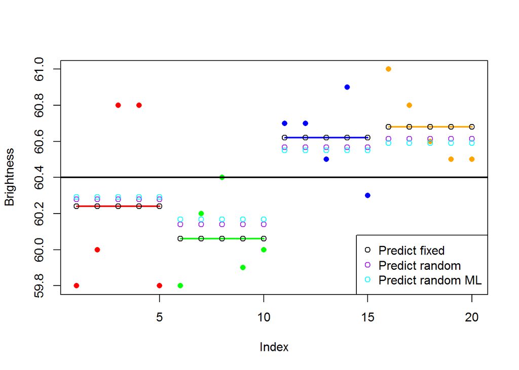

```r
md.fixed.predict<-predict(md.fixed)
md.random.predict<-predict(md.random)
md.random.ML.predict<-predict(md.random.ML)
matplot(1:length(pulp$bright),plotData[,1:4],col=c("red","green","blue","orange"),
        pch=16,ylab="Brightness",xlab="Index")
lines(1:length(pulp$bright),plotData[,5],col="red",lwd=2)
lines(1:length(pulp$bright),plotData[,6],col="green",lwd=2)
lines(1:length(pulp$bright),plotData[,7],col="blue",lwd=2)
lines(1:length(pulp$bright),plotData[,8],col="orange",lwd=2)
abline(h=grand,col="black",lwd=2)
points(1:length(pulp$bright),md.fixed.predict)
points(1:length(pulp$bright),md.random.predict,col="purple")
points(1:length(pulp$bright),md.random.ML.predict,col="cyan")
legend("bottomright",legend=c("Predict fixed","Predict random","Predict random ML"),
       col=c("black","purple","cyan"),pch=1)
```

## 1.1 Prediction by random effect model

Calculate fixed effects.

```r
grand<-mean(pulp$bright)
gr.a<-mean(subset(pulp,operator=="a")$bright)
gr.b<-mean(subset(pulp,operator=="b")$bright)
gr.c<-mean(subset(pulp,operator=="c")$bright)
gr.d<-mean(subset(pulp,operator=="d")$bright)
fixedEffects<-c(gr.a,gr.b,gr.c,gr.d)-grand
```

```r
fixedEffects
```

```
## [1] -0.16 -0.34  0.22  0.28
```

Compare fixed effects with random effects to understand prediction by the random effects model.

```r
fixedEffects/ranef(md.random)$operator
```

```
##   (Intercept)
## a    1.312118
## b    1.312118
## c    1.312118
## d    1.312118
```

The ratio shows the shrinkage factor.

Calculate the shrinkage factor using maximum likelihood estimates:

```r
fixedEffects/ranef(md.random.ML)$operator
```

```
##   (Intercept)
## a    1.464481
## b    1.464481
## c    1.464481
## d    1.464481
```

ML method produces higher shrinkage.

Prediction by random effect model is done as follows:

1. If brightness is predicted for new operator then prediction is the grand mean (fixed effect):

```r
fixef(md.random)
```

```
## (Intercept)
##        60.4
```

2. If brightness is predicted for one of the operators selected earlier then the prediction is adjusted by estimated random effect:

```r
fixef(md.random)+ranef(md.random)$operator
```

```
##   (Intercept)
## a    60.27806
## b    60.14088
## c    60.56767
## d    60.61340
```

Such predicting method is called **Best Linear Unbiased Predictor (BLUP)**. Compare it with the otput of `predict()`

```r
unique(predict(md.random))
```

```
## [1] 60.27806 60.14088 60.56767 60.61340
```

# 2 Blocks as Random Effects

Blocks usually represent effects that are not of direct interest, but cannot be avoided.

For example, response to a medicine may have slight differences for females and males. But the medicine is going to be prescribed regardless of gender anyway. So, grouping by gender represents blocks.

In the following example from page 161 4 processes of production of penicillin (4 treatments) are compared when blends of raw material, corn steep liquor, represent blocks.

```r
data(penicillin)
penicillin
```

```
##    treat  blend yield
## 1      A Blend1    89
## 2      B Blend1    88
## 3      C Blend1    97
## 4      D Blend1    94
## 5      A Blend2    84
## 6      B Blend2    77
## 7      C Blend2    92
## 8      D Blend2    79
## 9      A Blend3    81
## 10     B Blend3    87
## 11     C Blend3    87
## 12     D Blend3    85
## 13     A Blend4    87
## 14     B Blend4    92
## 15     C Blend4    89
## 16     D Blend4    84
## 17     A Blend5    79
## 18     B Blend5    81
## 19     C Blend5    80
## 20     D Blend5    88
```

```r
summary(penicillin)
```

```
##  treat    blend       yield
##  A:5   Blend1:4   Min.   :77
##  B:5   Blend2:4   1st Qu.:81
##  C:5   Blend3:4   Median :87
##  D:5   Blend4:4   Mean   :86
##        Blend5:4   3rd Qu.:89
##                   Max.   :97
```

Fit linear model.

```r
lmod <- lm(yield ~ blend + treat, penicillin)
summary(lmod)
```

```
##
## Call:
## lm(formula = yield ~ blend + treat, data = penicillin)
##
## Residuals:
##    Min     1Q Median     3Q    Max
##  -5.00  -2.25  -0.50   2.25   6.00
##
## Coefficients:
##             Estimate Std. Error t value Pr(>|t|)
## (Intercept)   90.000      2.745  32.791  4.1e-13 ***
## blendBlend2   -9.000      3.069  -2.933  0.01254 *
## blendBlend3   -7.000      3.069  -2.281  0.04159 *
## blendBlend4   -4.000      3.069  -1.304  0.21686
## blendBlend5  -10.000      3.069  -3.259  0.00684 **
## treatB         1.000      2.745   0.364  0.72194
## treatC         5.000      2.745   1.822  0.09351 .
## treatD         2.000      2.745   0.729  0.48018
## ---
## Signif. codes:  0 '***' 0.001 '**' 0.01 '*' 0.05 '.' 0.1 ' ' 1
##
## Residual standard error: 4.34 on 12 degrees of freedom
## Multiple R-squared:  0.5964, Adjusted R-squared:  0.361
## F-statistic: 2.534 on 7 and 12 DF,  p-value: 0.07535
```

```r
anova(lmod)
```

```
## Analysis of Variance Table
##
## Response: yield
##           Df Sum Sq Mean Sq F value  Pr(>F)
## blend      4    264  66.000  3.5044 0.04075 *
## treat      3     70  23.333  1.2389 0.33866
## Residuals 12    226  18.833
## ---
## Signif. codes:  0 '***' 0.001 '**' 0.01 '*' 0.05 '.' 0.1 ' ' 1
```

```r
coef(lmod)
```

```
## (Intercept) blendBlend2 blendBlend3 blendBlend4 blendBlend5      treatB
##          90          -9          -7          -4         -10           1
##      treatC      treatD
##           5           2
```

We do not see significant difference between treatments.  
But there is difference between the blends.  
Blend appears to be more important than treatment.

Fit `lmer()` using `blend` as random effect, but treatment as fixed effect.  
This corresponds to randomly selecting a blend from population of blends.

```r
mmod <- lmer(yield ~ treat + (1|blend), penicillin)
summary(mmod)
```

```
## Linear mixed model fit by REML ['lmerMod']
## Formula: yield ~ treat + (1 | blend)
##    Data: penicillin
##
## REML criterion at convergence: 103.8
##
## Scaled residuals:
##     Min      1Q  Median      3Q     Max
## -1.4152 -0.5017 -0.1644  0.6830  1.2836
##
## Random effects:
##  Groups   Name        Variance Std.Dev.
##  blend    (Intercept) 11.79    3.434
##  Residual             18.83    4.340
## Number of obs: 20, groups:  blend, 5
##
## Fixed effects:
##             Estimate Std. Error t value
## (Intercept)   84.000      2.475   33.94
## treatB         1.000      2.745    0.36
## treatC         5.000      2.745    1.82
## treatD         2.000      2.745    0.73
##
## Correlation of Fixed Effects:
##        (Intr) treatB treatC
## treatB -0.555
## treatC -0.555  0.500
## treatD -0.555  0.500  0.500
```

Note that the residual variance is the same for both models.  
The treatment effects are also the same.

Calculate fixed blend effects.

```r
grMean<-mean(penicillin$yield)
bl1.mean<-mean(subset(penicillin,blend=="Blend1")$yield)
bl2.mean<-mean(subset(penicillin,blend=="Blend2")$yield)
bl3.mean<-mean(subset(penicillin,blend=="Blend3")$yield)
bl4.mean<-mean(subset(penicillin,blend=="Blend4")$yield)
bl5.mean<-mean(subset(penicillin,blend=="Blend5")$yield)
(fixedBlend<-c(bl1.mean,bl2.mean,bl3.mean,bl4.mean,bl5.mean)-grMean)
```

```
## [1]  6 -3 -1  2 -4
```

Compare them with the estimated random effects.

```r
ranef(mmod)$blend
```

```
##        (Intercept)
## Blend1   4.2878788
## Blend2  -2.1439394
## Blend3  -0.7146465
## Blend4   1.4292929
## Blend5  -2.8585859
```

The random effects are shrunk version of fixed blend effects

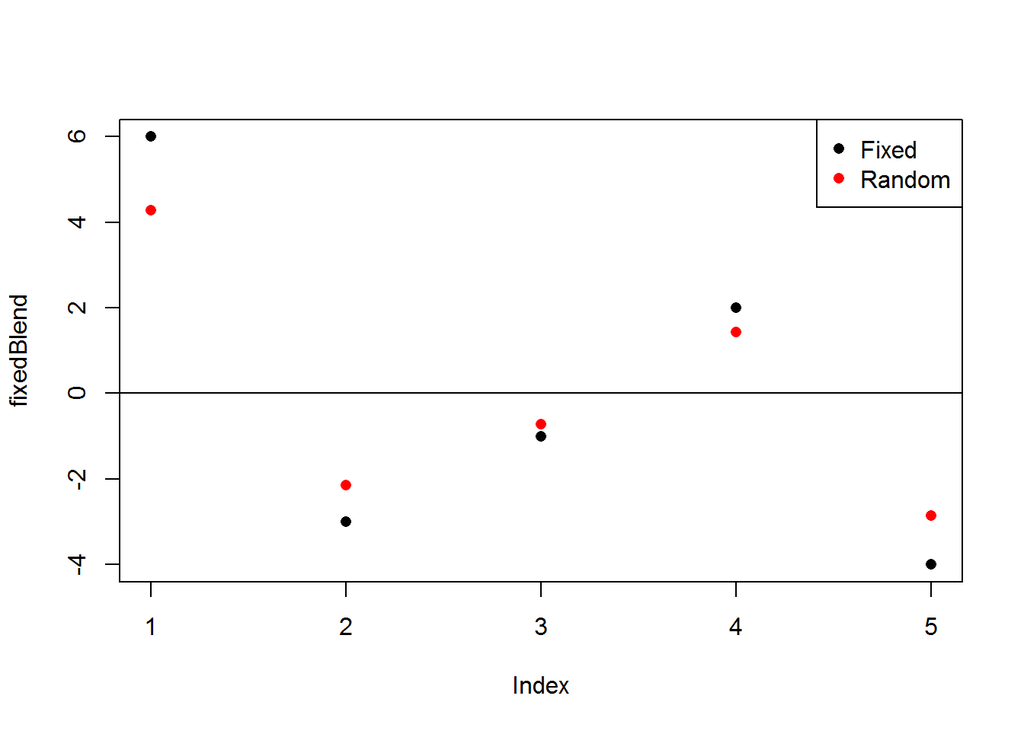

```r
plot(fixedBlend,pch=16)
points(ranef(mmod)$blend,pch=16,col="red")
abline(h=0)
legend("topright",legend=c("Fixed","Random"),pch=16,col=c("black","red"))
```

Test the significance of fixed effects using `anova()`

```r
anova(mmod)
```

```
## Analysis of Variance Table
##       Df Sum Sq Mean Sq F value
## treat  3     70  23.333  1.2389
```

The result is identical with ANOVA of `lmod`.  
This is always the case when design is balanced, i.e. numbers of observations in groups are equal.

Also test the fixed treatments effects using maximum likelihood ratio test.  
We need to use `REML=F` for that.

```r
amod <- lmer(yield ~ treat + (1|blend), penicillin, REML=F)
nmod <- lmer(yield ~ 1 + (1|blend), penicillin, REML=F)
anova(amod,nmod)
```

```
## Data: penicillin
## Models:
## nmod: yield ~ 1 + (1 | blend)
## amod: yield ~ treat + (1 | blend)
##      Df    AIC    BIC  logLik deviance  Chisq Chi Df Pr(>Chisq)
## nmod  3 127.33 130.31 -60.662   121.33
## amod  6 129.28 135.25 -58.639   117.28 4.0474      3     0.2564
```

Equivalence of models is not rejected.

We need to use ML method (`REML=F`) because under `REML` comparison of models with different fixed effects is not allowed: `REML` maximizing likelihood function without fixed effects which makes models with different fixed effects not comparable.

## 2.1 Longitudinal Data

In repeated measures designs same individual is studied multiple times.  
If observations of the same individual are collected in time then the design is called **longitudinal study** or *panel study**.

Look at the example on page 184.

In this example consider results of Panel Study of Income Dynamics (PSID) that started in 1968.

```r
data(psid)
head(psid)
```

```
##   age educ sex income year person
## 1  31   12   M   6000   68      1
## 2  31   12   M   5300   69      1
## 3  31   12   M   5200   70      1
## 4  31   12   M   6900   71      1
## 5  31   12   M   7500   72      1
## 6  31   12   M   8000   73      1
```

Plot the data

```r
suppressWarnings(library(lattice))
```

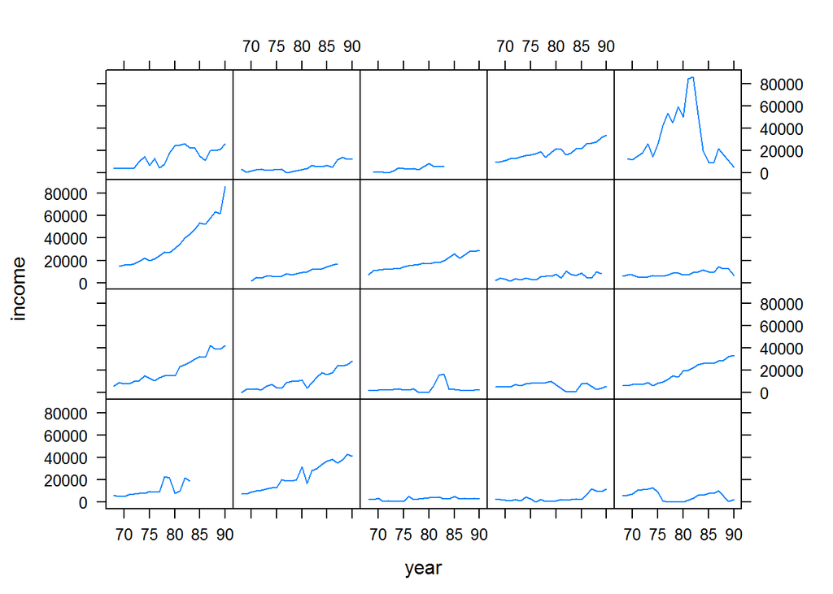

```r
xyplot(income ~ year | person, psid, type="l", subset=(person < 21),strip=FALSE)
```

The first 20 individuals are shown on the graph.  
Some have slowly increasing income, typical for steady secure jobs.  
Some are more irregular.

Group the data by sex.

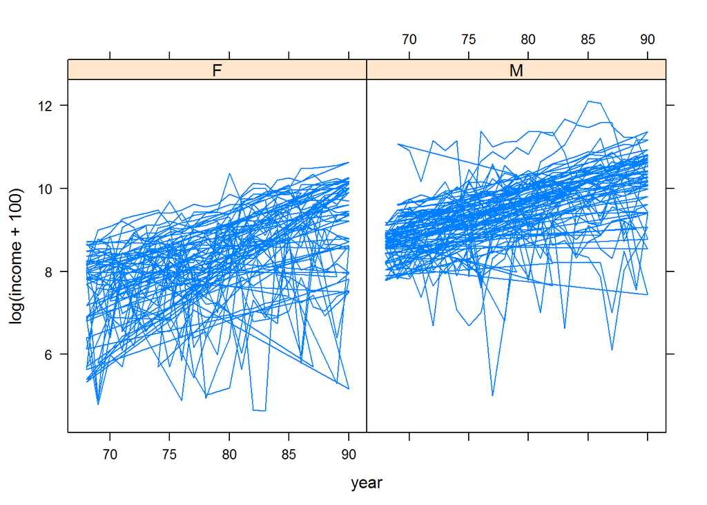

```r
xyplot(log(income+100) ~ year | sex, psid, type="l")
```

To remove the effect of very low salary briefly, add $100 to all incomes.  
**What can you tell by looking at the incomes by gender?**

Fit a line to each subject of the first 20 group after centering the predictor at median level.

```r
lmod <- lm(log(income) ~ I(year-78), subset=(person==1), psid)
coef(lmod)
```

```
##  (Intercept) I(year - 78)
##    9.3999568    0.0842667
```

Now do the same for the whole sample.

```r
slopes <- numeric(85);intercepts <- numeric(85)
for(i in 1:85){
lmod <- lm(log(income) ~ I(year-78), subset=(person==i), psid)
intercepts[i] <- coef(lmod)[1]
slopes[i] <- coef(lmod)[2]
}
```

Plot the results.

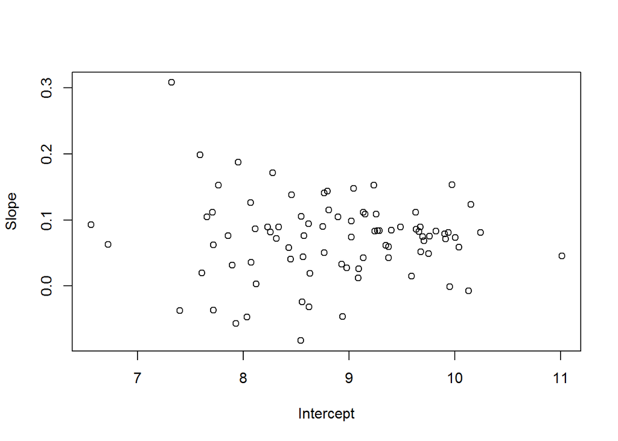

```r
plot(intercepts,slopes,xlab="Intercept",ylab="Slope")
```

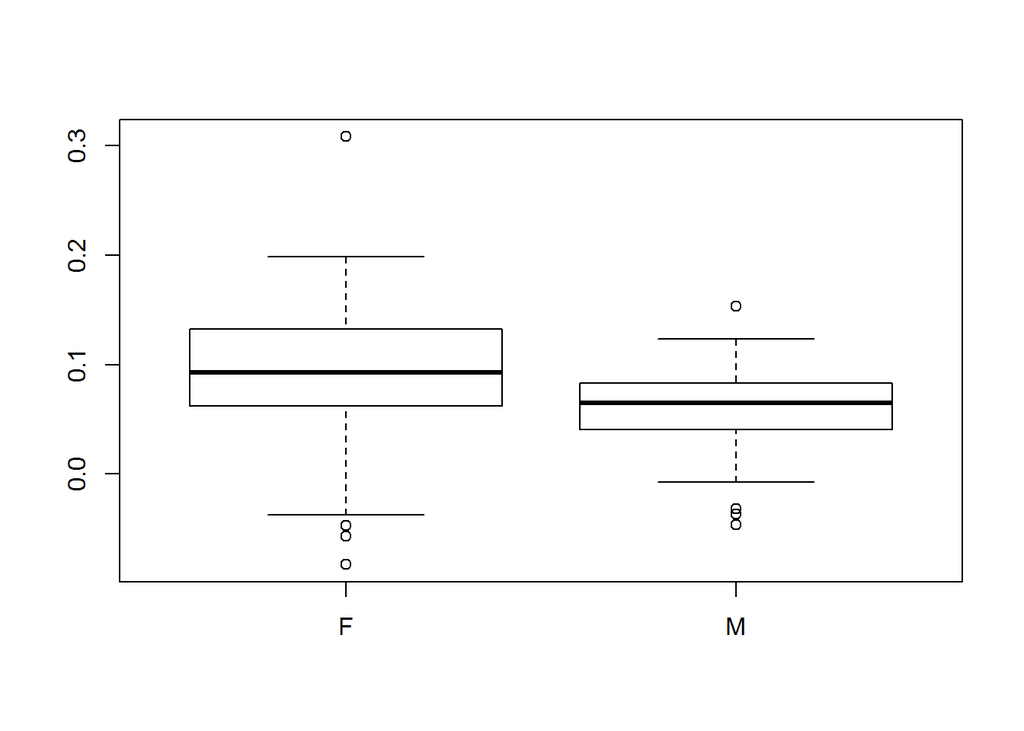

```r
psex <- psid$sex[match(1:85,psid$person)]
boxplot(split(slopes,psex))
```

Compare the slopes using t-test.

```r
t.test(slopes[psex=="M"],slopes[psex=="F"])
```

```
##
##  Welch Two Sample t-test
##
## data:  slopes[psex == "M"] and slopes[psex == "F"]
## t = -2.3786, df = 56.736, p-value = 0.02077
## alternative hypothesis: true difference in means is not equal to 0
## 95 percent confidence interval:
##  -0.05916871 -0.00507729
## sample estimates:
##  mean of x  mean of y
## 0.05691046 0.08903346
```

Also compare incomes at the intercept.

```r
t.test(intercepts[psex=="M"],intercepts[psex=="F"])
```

```
##
##  Welch Two Sample t-test
##
## data:  intercepts[psex == "M"] and intercepts[psex == "F"]
## t = 8.2199, df = 79.719, p-value = 3.065e-12
## alternative hypothesis: true difference in means is not equal to 0
## 95 percent confidence interval:
##  0.8738792 1.4322218
## sample estimates:
## mean of x mean of y
##  9.382325  8.229275
```

The results show that men have significantly higher incomes.  
But women have significantly higher slope.

Can the income change be predicted by gender, age and education level?  
Fit mixed effect model.

Use random slope and intercept per subject.

```r
psid$cyear <- psid$year-78
mmod <- lmer(log(income) ~ cyear*sex +age+educ+(cyear|person),psid)
summary(mmod)
```

```
## Linear mixed model fit by REML ['lmerMod']
## Formula: log(income) ~ cyear * sex + age + educ + (cyear | person)
##    Data: psid
##
## REML criterion at convergence: 3819.8
##
## Scaled residuals:
##      Min       1Q   Median       3Q      Max
## -10.2310  -0.2134   0.0795   0.4147   2.8254
##
## Random effects:
##  Groups   Name        Variance Std.Dev. Corr
##  person   (Intercept) 0.2817   0.53071
##           cyear       0.0024   0.04899  0.19
##  Residual             0.4673   0.68357
## Number of obs: 1661, groups:  person, 85
##
## Fixed effects:
##             Estimate Std. Error t value
## (Intercept)  6.67420    0.54333  12.284
## cyear        0.08531    0.00900   9.480
## sexM         1.15031    0.12129   9.484
## age          0.01093    0.01352   0.808
## educ         0.10421    0.02144   4.861
## cyear:sexM  -0.02631    0.01224  -2.150
##
## Correlation of Fixed Effects:
##            (Intr) cyear  sexM   age    educ
## cyear       0.020
## sexM       -0.104 -0.098
## age        -0.874  0.002 -0.026
## educ       -0.597  0.000  0.008  0.167
## cyear:sexM -0.003 -0.735  0.156 -0.010 -0.011
```

The fitted model is:

$$\ln{income_{i,j}}=\mu+\beta_i year_i+\beta_s sex_j+\beta_{y,s} sex_j \times year_i +\beta_e education_j +\beta_a age_j +\gamma^0_j+\gamma^1_j year_i +\epsilon_{i,j},$$
where $\gamma^0_j \sim Norm(0,\sigma_{\gamma^0})$, $\gamma^1_j \sim Norm(0,\sigma_{\gamma^1})$, $\rho(\gamma^0,\gamma^1)=\rho$, $i$ denotes year and $j$ denotes individual.

Conclusions:

Analysis of residuals shows that the model fit is questionable.  
The results should be treated with caution.

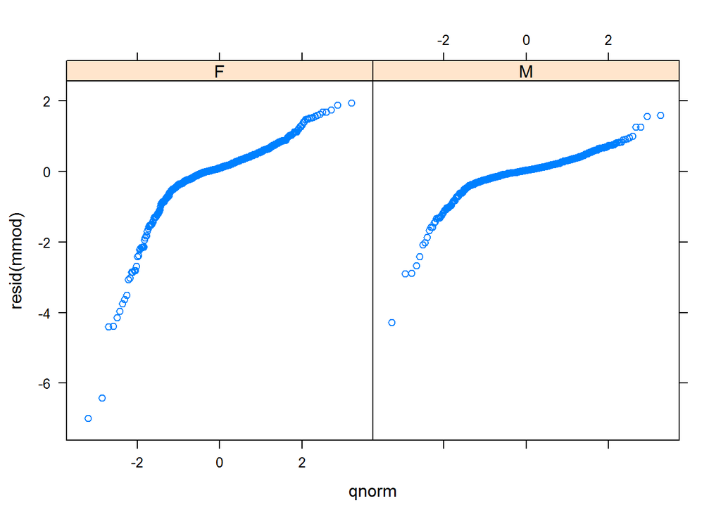

```r
qqmath(~resid(mmod) | sex, psid)
```

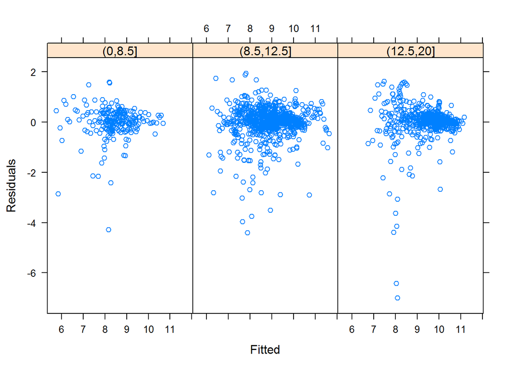

```r
xyplot(resid(mmod) ~ fitted(mmod) | cut(educ,c(0,8.5,12.5,20)), psid, layout=c(3,1),xlab="Fitted",ylab="Residuals")
```

# 3 Mixed Effects in GLM Framework

Look at example on page 199.

```r
head(ctsib)
```

```
##   Subject  Sex Age Height Weight Surface Vision CTSIB
## 1       1 male  22    176   68.2    norm   open     1
## 2       1 male  22    176   68.2    norm   open     1
## 3       1 male  22    176   68.2    norm closed     2
## 4       1 male  22    176   68.2    norm closed     2
## 5       1 male  22    176   68.2    norm   dome     1
## 6       1 male  22    176   68.2    norm   dome     2
```

```r
#data(ctsib)
ctsib$stable<-ifelse(ctsib$CTSIB==1,1,0)
head(ctsib)
```

```
##   Subject  Sex Age Height Weight Surface Vision CTSIB stable
## 1       1 male  22    176   68.2    norm   open     1      1
## 2       1 male  22    176   68.2    norm   open     1      1
## 3       1 male  22    176   68.2    norm closed     2      0
## 4       1 male  22    176   68.2    norm closed     2      0
## 5       1 male  22    176   68.2    norm   dome     1      1
## 6       1 male  22    176   68.2    norm   dome     2      0
```

```r
summary(ctsib)
```

```
##     Subject          Sex           Age            Height
##  Min.   : 1.00   female:240   Min.   :18.00   Min.   :142.0
##  1st Qu.:10.75   male  :240   1st Qu.:21.75   1st Qu.:166.8
##  Median :20.50                Median :25.50   Median :173.0
##  Mean   :20.50                Mean   :26.80   Mean   :172.1
##  3rd Qu.:30.25                3rd Qu.:33.00   3rd Qu.:180.2
##  Max.   :40.00                Max.   :38.00   Max.   :190.0
##      Weight       Surface       Vision        CTSIB           stable
##  Min.   : 44.20   foam:240   closed:160   Min.   :1.000   Min.   :0.0000
##  1st Qu.: 60.65   norm:240   dome  :160   1st Qu.:2.000   1st Qu.:0.0000
##  Median : 68.00              open  :160   Median :2.000   Median :0.0000
##  Mean   : 71.14                           Mean   :1.919   Mean   :0.2375
##  3rd Qu.: 83.50                           3rd Qu.:2.000   3rd Qu.:0.0000
##  Max.   :102.40                           Max.   :4.000   Max.   :1.0000
```

Fit binomial regression ignoring the subject information.

```r
gf<-glm(stable~Sex+Age+Height+Weight+Surface+Vision,family=binomial,data=ctsib)
summary(gf)
```

```
##
## Call:
## glm(formula = stable ~ Sex + Age + Height + Weight + Surface +
##     Vision, family = binomial, data = ctsib)
##
## Deviance Residuals:
##      Min        1Q    Median        3Q       Max
## -2.28763  -0.54392  -0.13884  -0.05483   2.48130
##
## Coefficients:
##              Estimate Std. Error z value Pr(>|z|)
## (Intercept)  7.277449   3.803987   1.913 0.055734 .
## Sexmale      1.401577   0.516231   2.715 0.006627 **
## Age          0.002521   0.024307   0.104 0.917390
## Height      -0.096413   0.026837  -3.593 0.000327 ***
## Weight       0.043503   0.018002   2.417 0.015665 *
## Surfacenorm  3.967515   0.447179   8.872  < 2e-16 ***
## Visiondome   0.363753   0.383218   0.949 0.342516
## Visionopen   3.187501   0.416001   7.662 1.83e-14 ***
## ---
## Signif. codes:  0 '***' 0.001 '**' 0.01 '*' 0.05 '.' 0.1 ' ' 1
##
## (Dispersion parameter for binomial family taken to be 1)
##
##     Null deviance: 526.25  on 479  degrees of freedom
## Residual deviance: 295.20  on 472  degrees of freedom
## AIC: 311.2
##
## Number of Fisher Scoring iterations: 6
```

Adding a fixed subject effect.

```r
gfs<-glm(stable~Sex+Age+Height+Weight+Surface+Vision+factor(Subject),family=binomial,data=ctsib)
anova(gf,gfs,test="Chi")
```

```
## Analysis of Deviance Table
##
## Model 1: stable ~ Sex + Age + Height + Weight + Surface + Vision
## Model 2: stable ~ Sex + Age + Height + Weight + Surface + Vision + factor(Subject)
##   Resid. Df Resid. Dev Df Deviance  Pr(>Chi)
## 1       472     295.20
## 2       435     179.43 37   115.77 4.812e-10 ***
## ---
## Signif. codes:  0 '***' 0.001 '**' 0.01 '*' 0.05 '.' 0.1 ' ' 1
```

```r
summary(gfs)
```

```
##
## Call:
## glm(formula = stable ~ Sex + Age + Height + Weight + Surface +
##     Vision + factor(Subject), family = binomial, data = ctsib)
##
## Deviance Residuals:
##     Min       1Q   Median       3Q      Max
## -4.1908  -0.0903  -0.0036   0.0000   3.2228
##
## Coefficients: (2 not defined because of singularities)
##                     Estimate Std. Error z value Pr(>|z|)
## (Intercept)       -1.990e+15  2.184e+15  -0.911    0.362
## Sexmale           -6.792e+13  1.246e+14  -0.545    0.586
## Age                8.819e+12  3.647e+13   0.242    0.809
## Height            -5.220e+12  2.013e+13  -0.259    0.795
## Weight             4.080e+13  5.077e+13   0.804    0.422
## Surfacenorm        9.376e+00  1.647e+00   5.694 1.24e-08 ***
## Visiondome         8.046e-01  6.142e-01   1.310    0.190
## Visionopen         8.052e+00  1.616e+00   4.984 6.24e-07 ***
## factor(Subject)2   5.058e+13  1.283e+14   0.394    0.694
## factor(Subject)3  -1.576e+14  2.019e+14  -0.781    0.435
## factor(Subject)4  -1.743e+14  2.059e+14  -0.847    0.397
## factor(Subject)5   7.704e+13  6.341e+13   1.215    0.224
## factor(Subject)6  -3.920e+14  6.205e+14  -0.632    0.528
## factor(Subject)7  -7.677e+14  6.929e+14  -1.108    0.268
## factor(Subject)8   7.592e+14  7.983e+14   0.951    0.342
## factor(Subject)9   1.798e+14  3.630e+14   0.495    0.620
## factor(Subject)10 -5.908e+14  4.991e+14  -1.184    0.236
## factor(Subject)11 -9.479e+14  1.113e+15  -0.851    0.395
## factor(Subject)12 -9.365e+14  8.039e+14  -1.165    0.244
## factor(Subject)13 -5.927e+14  7.490e+14  -0.791    0.429
## factor(Subject)14  3.475e+14  9.610e+14   0.362    0.718
## factor(Subject)15  1.742e+14  5.377e+14   0.324    0.746
## factor(Subject)16  7.514e+14  6.742e+14   1.114    0.265
## factor(Subject)17 -9.192e+14  7.526e+14  -1.221    0.222
## factor(Subject)18 -1.887e+14  4.641e+14  -0.407    0.684
## factor(Subject)19 -3.160e+14  3.712e+14  -0.851    0.395
## factor(Subject)20  5.349e+13  2.970e+14   0.180    0.857
## factor(Subject)21 -1.348e+14  2.355e+14  -0.572    0.567
## factor(Subject)22  6.453e+14  7.698e+14   0.838    0.402
```

[output cut: 13 more lines]

```
## factor(Subject)36  2.380e+14  2.355e+14   1.010    0.312
## factor(Subject)37 -2.390e+12  7.045e+14  -0.003    0.997
## factor(Subject)38 -6.398e+14  6.431e+14  -0.995    0.320
## factor(Subject)39         NA         NA      NA       NA
## factor(Subject)40         NA         NA      NA       NA
## ---
## Signif. codes:  0 '***' 0.001 '**' 0.01 '*' 0.05 '.' 0.1 ' ' 1
##
## (Dispersion parameter for binomial family taken to be 1)
##
##     Null deviance: 526.25  on 479  degrees of freedom
## Residual deviance: 179.43  on 435  degrees of freedom
## AIC: 269.43
##
## Number of Fisher Scoring iterations: 25
```

The ANOVA table shows strong subject effect.  
But after adding the fixed effect subject parameters of gender, age, height and weight are not significant.  
This is because each individual makes a dummy variable for which these factors are constant.

One way of fitting generalized model with mixed effects is `glmmPQL()` from `MASS`.  
`PQL` stands for Penalized Quazi-Likelihood method.

Fit `glmmPQL()`.

```r
suppressWarnings(library(MASS))
gg<-glmmPQL(stable~Sex+Age+Height+Weight+Surface+Vision,random=~1|Subject,family=binomial,data=ctsib)
summary(gg)
```

```
## Linear mixed-effects model fit by maximum likelihood
##  Data: ctsib
##   AIC BIC logLik
##    NA  NA     NA
##
## Random effects:
##  Formula: ~1 | Subject
##         (Intercept)  Residual
## StdDev:    3.060712 0.5906232
##
## Variance function:
##  Structure: fixed weights
##  Formula: ~invwt
## Fixed effects: stable ~ Sex + Age + Height + Weight + Surface + Vision
##                 Value Std.Error  DF   t-value p-value
## (Intercept) 15.571494 13.498304 437  1.153589  0.2493
## Sexmale      3.355340  1.752614  35  1.914478  0.0638
## Age         -0.006638  0.081959  35 -0.080992  0.9359
## Height      -0.190819  0.092023  35 -2.073601  0.0455
## Weight       0.069467  0.062857  35  1.105155  0.2766
## Surfacenorm  7.724078  0.573578 437 13.466492  0.0000
## Visiondome   0.726464  0.325933 437  2.228873  0.0263
## Visionopen   6.485257  0.543980 437 11.921876  0.0000
##  Correlation:
##             (Intr) Sexmal Age    Height Weight Srfcnr Visndm
## Sexmale      0.488
## Age         -0.164  0.110
## Height      -0.963 -0.388  0.041
## Weight       0.368 -0.374 -0.168 -0.555
## Surfacenorm  0.051  0.116  0.023 -0.114  0.055
## Visiondome  -0.003  0.011  0.004 -0.017  0.011  0.087
## Visionopen   0.056  0.125  0.026 -0.116  0.049  0.788  0.377
##
## Standardized Within-Group Residuals:
##           Min            Q1           Med            Q3           Max
## -7.3825387643 -0.2333403344 -0.0233564299 -0.0004216629  9.9310682779
##
## Number of Observations: 480
## Number of Groups: 40
```

```r
names(gg)
```

```
##  [1] "modelStruct"  "dims"         "contrasts"    "coefficients"
##  [5] "varFix"       "sigma"        "apVar"        "logLik"
##  [9] "numIter"      "groups"       "call"         "terms"
## [13] "method"       "fitted"       "residuals"    "fixDF"
## [17] "na.action"    "data"         "family"
```

Plot predicted values in the form of response.  
Order the variables to select the cut-off level.

```r
decisionMakingMatrix<-cbind(ctsib$stable,predict(gg,type="response"))
head(decisionMakingMatrix)
```

```
##   [,1]      [,2]
## 1    1 0.9920552
## 1    1 0.9920552
## 1    0 0.1600318
## 1    0 0.1600318
## 1    1 0.2826149
## 1    0 0.2826149
```

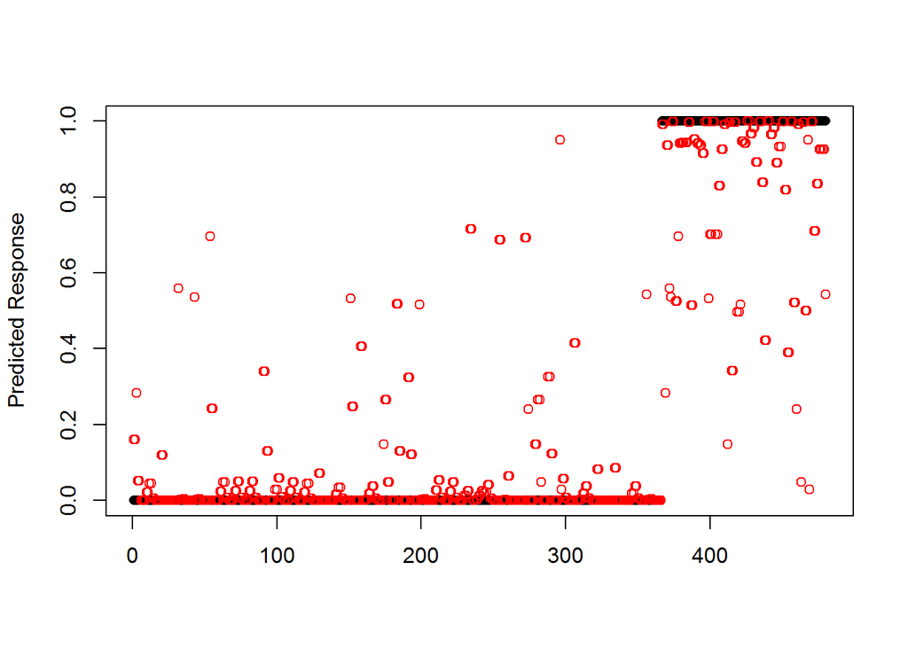

```r
matplot(decisionMakingMatrix[order(decisionMakingMatrix[,1]),],pch=c(16,1),ylab="Predicted Response")
```

```r
probabilityThreshold<-.5
decisionFrontier<-function(decisionMatrix,decisionThreshold){
  Result<-table(decisionMatrix[,1] != (decisionMatrix[,2] > decisionThreshold))/nrow(decisionMatrix)
  setNames(Result,c("Correct","Incorrect"))
}
decisionFrontier(decisionMakingMatrix,.5)
```

```
##    Correct  Incorrect
## 0.94166667 0.05833333
```

```r
(frontier<-t(rbind(seq(from=.2,to=.8,by=.05),
                sapply(seq(from=.2,to=.8,by=.05),function(z) decisionFrontier(decisionMakingMatrix,z)))))
```

```
##              Correct  Incorrect
##  [1,] 0.20 0.9208333 0.07916667
##  [2,] 0.25 0.9291667 0.07083333
##  [3,] 0.30 0.9375000 0.06250000
##  [4,] 0.35 0.9458333 0.05416667
##  [5,] 0.40 0.9416667 0.05833333
##  [6,] 0.45 0.9458333 0.05416667
##  [7,] 0.50 0.9416667 0.05833333
##  [8,] 0.55 0.9291667 0.07083333
##  [9,] 0.60 0.9291667 0.07083333
## [10,] 0.65 0.9291667 0.07083333
## [11,] 0.70 0.9375000 0.06250000
## [12,] 0.75 0.9291667 0.07083333
## [13,] 0.80 0.9291667 0.07083333
```

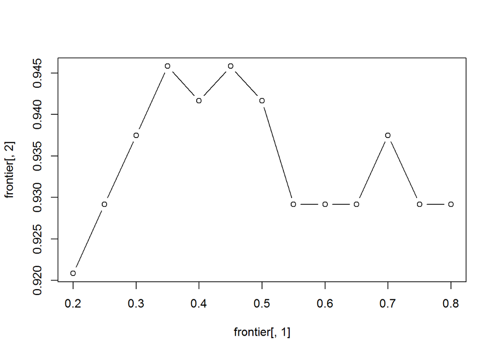

```r
matplot(frontier[,1],frontier[,2],type="b",pch=1)
```

```r
frontier[which.max(frontier[,2]),1]
```

```
##
## 0.35
```

# 4 Sleep deprivation study

This example is described in [Mixed-effects models project](http://lme4.r-forge.r-project.org/book/Ch4.pdf)

Data `sleepstudy` from library `lme4` come from the study by [G. Belenky, et al (2003), Patterns of performance degradation and restoration during sleep restriction and subsequent recovery: a sleep dose-response study](http://dev.spokane.wsu.edu/researchoutreach/Sleep/documents/2003JSR-Belenky-etal.pdf).

In the study a number of subjects from population of long-distance truck drivers were allowed only 3 hours of sleep each night during period of 10 days. Each day their reaction time was tested several times a day and averaged (measured in milliseconds).  
In the data set there are measurements of 18 drivers from the study.

```r
suppressWarnings(library(lattice))
```

```r
head(sleepstudy)
```

```
##   Reaction Days Subject
## 1 249.5600    0     308
## 2 258.7047    1     308
## 3 250.8006    2     308
## 4 321.4398    3     308
## 5 356.8519    4     308
## 6 414.6901    5     308
```

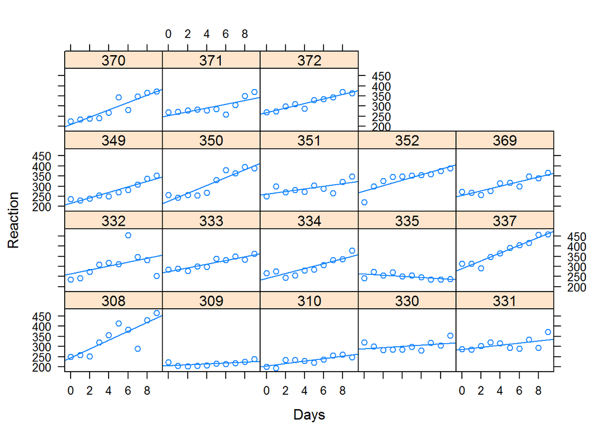

```r
xyplot(Reaction~Days|Subject,sleepstudy,type=c("p","r"))
```

It might be instructive to compare individual slopes and intercepts of subjects using linear models.  
But there are reasons to consider random effects: subjects are selected randomly from a population and it may be important to draw conclusions about the whole population

As a result select a mixed model with intercept and slope as fixed effects and individual intercept and slope for each subject as random effects.

Fit 2 variations of the model:

- One has conditional correlation between random effects of the same subject which allows to suggest in particular that individuals with initially higher reaction time are affected by sleep deprivation more.
- The second model has independent random effects.

## 4.1 Model allowing correlation

Fit a model with fixed intercept and slope showing the general tendency and individual slopes and intercepts for each subject.

Fit model `fm8` using `lmer()` with parameter `REML=F` including random effects for individual intercepts and slopes.

(Skipped code)

```r
head(ranef(fm8)$Subject)
```

```
##     (Intercept)       Days
## 308    2.815680  9.0755344
## 309  -40.048485 -8.6440676
## 310  -38.433152 -5.5133789
## 330   22.832297 -4.6587507
## 331   21.549991 -2.9445203
## 332    8.815587 -0.2352092
```

```r
confint(fm8)
```

```
## Computing profile confidence intervals ...
```

```
##                   2.5 %     97.5 %
## .sig01       14.3815997  37.715996
## .sig02       -0.4815007   0.684986
## .sig03        3.8011641   8.753383
## .sigma       22.8982669  28.857997
## (Intercept) 237.6806955 265.129515
## Days          7.3586533  13.575919
```

The model has 6 parameters:

- Variance of subject intercept: its confidence interval is called `.sig01` and shows significance
- Variance of subject slope: confidence interval `.sig03` shows significance
- Correlation between random slope and intercept: confidence interval `.sig02` shows insignificance
- Residual variance: confidence interval `.sigma`
- Fixed intercept effect, significant
- Fixed slope effect, significant.

The fixed effect intercept shows that typical initial reaction time (0 days with restricted sleep time) is about 250 milliseconds.  
Then on average each day of sleep deprivation increases reaction time by a little over 10 milliseconds. Residual subject-to-subject standard deviation is 25.592 shows that individual intercepts are expected to change within interval $250 \pm 50$ milliseconds or between 200 and 300 milliseconds.  
For slopes we see that fixed slope is at 10.467 and random slope standard deviation is 5.7, so expected variation of slopes is $10.5 \pm 2 \cdot 5.7$ or between -0.9 and 21.9.

Check observed individual slopes and intercepts.

```r
slopes<-numeric(18);intercepts<-numeric(18)
strtoi(names(table(sleepstudy$Subject)))
```

```
##  [1] 308 309 310 330 331 332 333 334 335 337 349 350 351 352 369 370 371
## [18] 372
```

```r
for (i in 1:18) {
  lmod<-lm(Reaction~Days,subset=(sleepstudy$Subject==strtoi(names(table(sleepstudy$Subject)))[i]),
           sleepstudy)
  intercepts[i]<-coef(lmod)[1]
  slopes[i]=coef(lmod)[2]
}
summary(intercepts)
```

```
##    Min. 1st Qu.  Median    Mean 3rd Qu.    Max.
##   203.5   229.4   258.1   251.4   273.0   290.1
```

```r
summary(slopes)
```

```
##    Min. 1st Qu.  Median    Mean 3rd Qu.    Max.
##  -2.881   6.195  10.430  10.470  13.550  21.760
```

The upper level of slopes variation is consistent with these calculations.  
However the lower end of the range is lower than expected.

Correlation between individual slopes and intercepts is insignificant.  
This means that there is no evidence of relationship between initial reaction time and the rate of change as a result of sleep deprivation.

Check copula to confirm no non-linear relationship between slopes and intercepts.

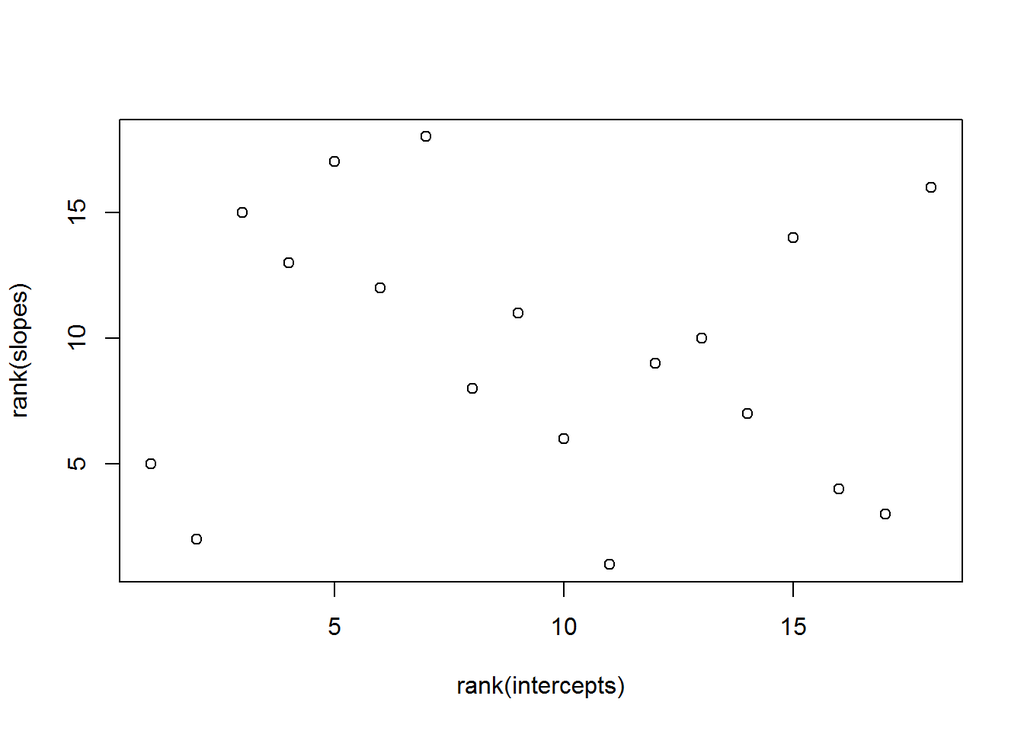

```r
plot(rank(intercepts),rank(slopes))
```

## 4.2 Model with uncorrelated random effects

In order to request an independent random effects we need to specify individual intercept and individual slope as two terms.  
However, formula `Reaction~1+Days+(1|Subject)+(Days|Subject)` is not going to work because `(Days|Subject)` is equivalent to `(1+Days|Subject)`.  
Set formula as `Reaction~1+Days+(1|Subject)+(0+Days|Subject)`.  
The last term in the formula can also be replaced with `(-1+Days|Subject)`.

```r
(fm9 <- lmer(Reaction~1+Days+(1|Subject)+(0+Days|Subject),sleepstudy,REML=F))
```

```
## Linear mixed model fit by maximum likelihood  ['lmerMod']
## Formula: Reaction ~ 1 + Days + (1 | Subject) + (0 + Days | Subject)
##    Data: sleepstudy
##       AIC       BIC    logLik  deviance  df.resid
## 1762.0033 1777.9680 -876.0016 1752.0033       175
## Random effects:
##  Groups    Name        Std.Dev.
##  Subject   (Intercept) 24.171
##  Subject.1 Days         5.799
##  Residual              25.556
## Number of obs: 180, groups:  Subject, 18
## Fixed Effects:
## (Intercept)         Days
##      251.41        10.47
```

```r
summary(fm9)
```

```
## Linear mixed model fit by maximum likelihood  ['lmerMod']
## Formula: Reaction ~ 1 + Days + (1 | Subject) + (0 + Days | Subject)
##    Data: sleepstudy
##
##      AIC      BIC   logLik deviance df.resid
##     1762     1778     -876     1752      175
##
## Scaled residuals:
##     Min      1Q  Median      3Q     Max
## -3.9535 -0.4673  0.0239  0.4625  5.1883
##
## Random effects:
##  Groups    Name        Variance Std.Dev.
##  Subject   (Intercept) 584.25   24.171
##  Subject.1 Days         33.63    5.799
##  Residual              653.12   25.556
## Number of obs: 180, groups:  Subject, 18
##
## Fixed effects:
##             Estimate Std. Error t value
## (Intercept)  251.405      6.708   37.48
## Days          10.467      1.519    6.89
##
## Correlation of Fixed Effects:
##      (Intr)
## Days -0.194
```

```r
head(ranef(fm9)$Subject)
```

```
##     (Intercept)       Days
## 308    1.854656  9.2364346
## 309  -40.022307 -8.6174730
## 310  -38.723163 -5.4343800
## 330   23.903320 -4.8581940
## 331   22.396322 -3.1048405
## 332    9.052001 -0.2821598
```

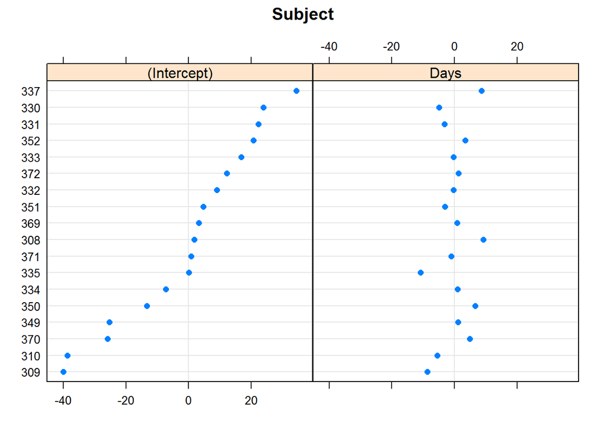

```r
dotplot(ranef(fm9))
```

```r
confint(fm9)
```

```
## Computing profile confidence intervals ...
```

```
##                  2.5 %     97.5 %
## .sig01       15.258647  37.786472
## .sig02        3.964074   8.769159
## .sigma       22.880555  28.787598
## (Intercept) 237.572148 265.238062
## Days          7.334067  13.600505
```

For this model there are still 2 random effects per subject, but this time there is no correlation between them.  
Now all parameters are significant.

## 4.3 Comparison of the two models

The models `fm8` and `fm9` are nested and can be compared by `anova()`.

```r
anova(fm9,fm8)
```

```
## Data: sleepstudy
## Models:
## fm9: Reaction ~ 1 + Days + (1 | Subject) + (0 + Days | Subject)
## fm8: Reaction ~ 1 + Days + (1 + Days | Subject)
##     Df    AIC    BIC  logLik deviance  Chisq Chi Df Pr(>Chisq)
## fm9  5 1762.0 1778.0 -876.00   1752.0
## fm8  6 1763.9 1783.1 -875.97   1751.9 0.0639      1     0.8004
```

The Chi-square statistic is small: 0.0639 relative to 1 degree of freedom, resulting in p-value of 0.8.  
So, the hypothesis of equivalence between the two models is not rejected.

## 4.4 Profile Zeta plots

Profile zeta plots show sensitivity of the model fit to change in the parameter.

```r
pr9<-profile(fm9)
head(pr9)
```

```
##       .zeta    .sig01   .sig02   .sigma (Intercept)     Days   .par
## 1 -3.935237  7.180616 6.645732 27.72169    251.4051 10.46729 .sig01
## 2 -3.501274  9.161541 6.463038 27.19314    251.4051 10.46729 .sig01
## 3 -3.037556 11.053538 6.300645 26.74056    251.4051 10.46729 .sig01
## 4 -2.551943 12.945926 6.162799 26.37341    251.4051 10.46729 .sig01
## 5 -2.049227 14.905365 6.049618 26.08796    251.4051 10.46729 .sig01
## 6 -1.532594 16.990396 5.959111 25.87438    251.4051 10.46729 .sig01
```

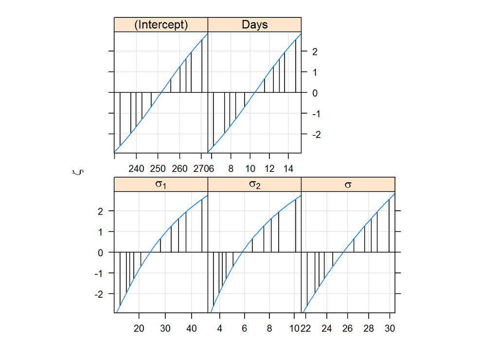

```r
xyplot(pr9,aspect=1.3)
```

Vertical lines show 50%, 80%, 90%, 95% and 99% confidence intervals.  
Values on x-axis are given by `confint()`.

```r
confint(pr9)
```

```
##                  2.5 %     97.5 %
## .sig01       15.258647  37.786472
## .sig02        3.964074   8.769159
## .sigma       22.880555  28.787598
## (Intercept) 237.572148 265.238062
## Days          7.334067  13.600505
```

Alternative view of profile zeta plot is

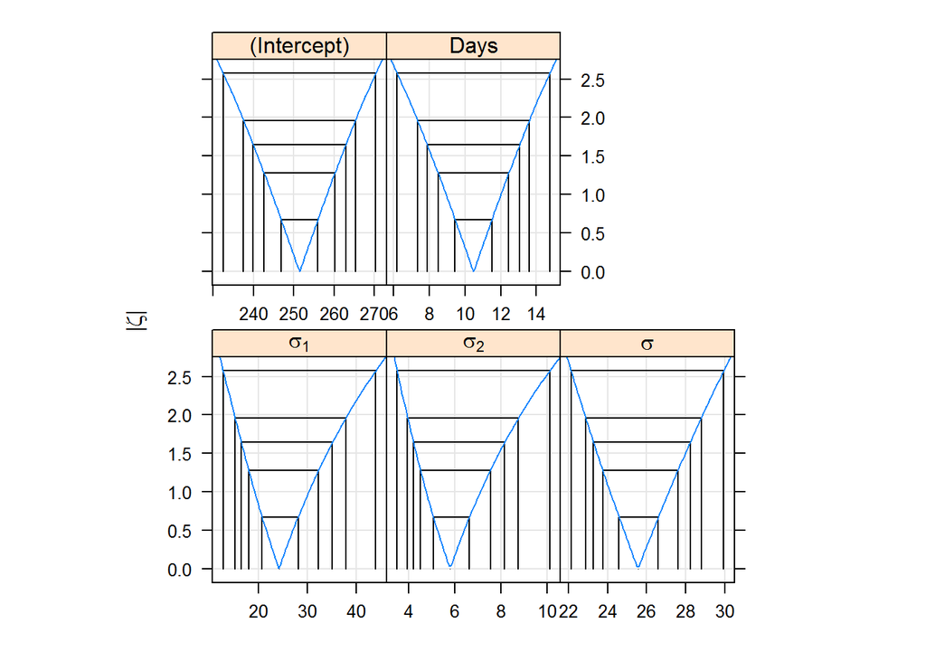

```r
xyplot(pr9,aspect=1.3,absVal=T)
```

Interpretation of zeta plots is similar to qq-plot.  
In ideal case it looks close to straight line, indicating that confidence intervals are suitable.

The graph shows appropriate shape of zeta plot for `Days`, `Intercept` and `sigma`, but confidence intervals for `.sigma1` and `.sigma2` are skewed.

Profile pairs plot is created by:

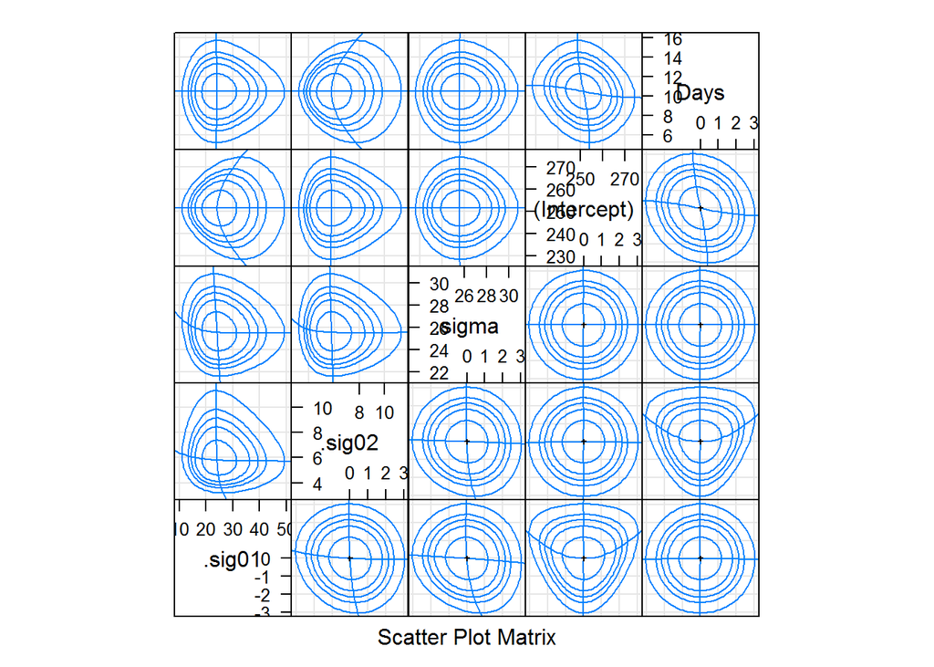

```r
splom(pr9)
```

Pattern between `.sigma1` and `Intercept` means that when fixed effect moves away from the estimate the corresponding random effects variance increases. Ideal case: circles, like for `.sigma02`-`Intercept`.

# 5 Oxford boys growth example

## 5.1 Data

This example is based on data `Oxboys` from package `nlme`. The data show records the growth (height) over time of 26 boys from Oxford. Each boy had his height measured on 9 occasions.

```r
data(Oxboys,package="nlme")
head(Oxboys)
```

```
## Grouped Data: height ~ age | Subject
##   Subject     age height Occasion
## 1       1 -1.0000  140.5        1
## 2       1 -0.7479  143.4        2
## 3       1 -0.4630  144.8        3
## 4       1 -0.1643  147.1        4
## 5       1 -0.0027  147.7        5
## 6       1  0.2466  150.2        6
```

Plot the data

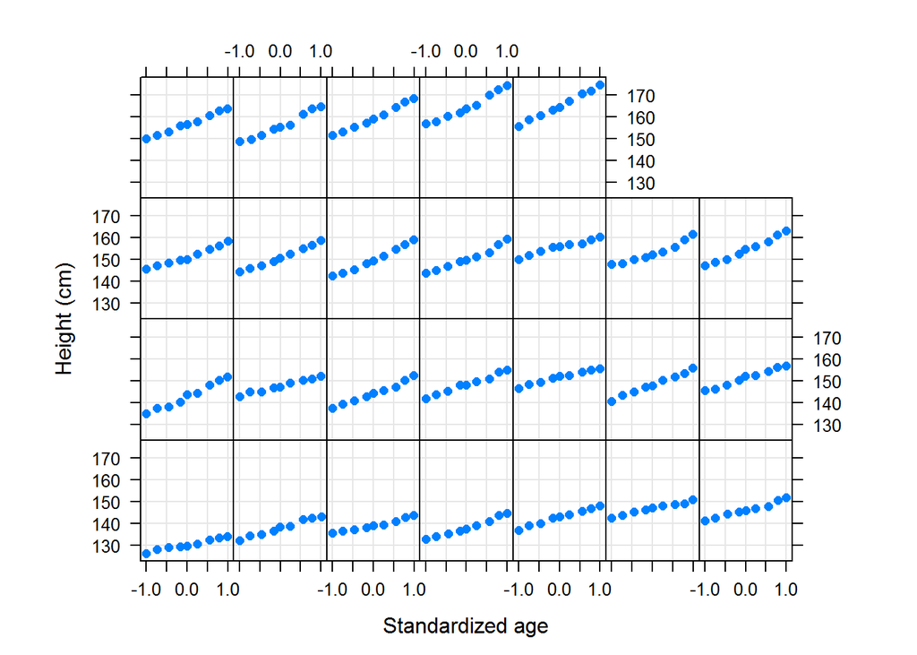

```r
xyplot(height~age|Subject,data=Oxboys,strip=FALSE,aspect=1.3,pch = 16,
       col.line="black",grid=TRUE,
       xlab="Standardized age",ylab="Height (cm)")
```

Or plot the same data with linear trends

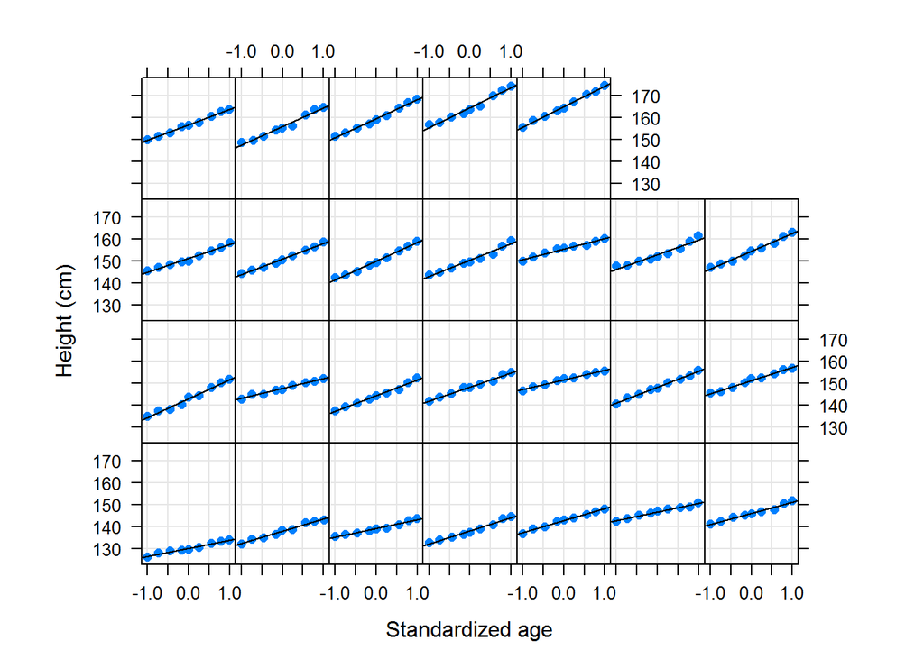

```r
xyplot(height~age|Subject,data=Oxboys,strip=FALSE,aspect=1.3,pch = 16,
       col.line="black",grid=TRUE,type=c("p","r"),
       xlab="Standardized age",ylab="Height (cm)")
```

## 5.2 Selecting model

Fit model with quadratic term and individual random intercept:

$$y_{i,j}=\beta_0+\alpha_i+\beta_1 x_{i,j}+\beta_2 x_{i,j}^2+\epsilon_{i,j},$$
where $i$ is the number of subject, $j$ is the number of occasion or repeated measurement, $y_{i,j}$ is height of subject $i$ on occasion $j$, $\alpha_i$ and $\epsilon_{i,j}$ are independent,
$$\alpha_i \sim N(0,\tau),~\epsilon_{i,j} \sim N(0,\sigma).$$
Parameters are: $\beta_0,\beta_1,\beta_2, \tau^2, \sigma^2$.

Create model `fm1` fitted with `lmer()` using formula corresponding to the model description above.  
Make parameter `REML=F`.

(Skipped Code)

Look at the properties of the fitted model.

```r
head(ranef(fm1)$Subject)
```

```
##    (Intercept)
## 10  -19.116669
## 26  -11.369746
## 25  -10.187880
## 9   -11.216627
## 2    -6.518312
## 6    -2.629451
```

```r
confint(fm1)
```

```
## Computing profile confidence intervals ...
```

```
##                   2.5 %     97.5 %
## .sig01        6.1825349  10.712013
## .sigma        1.1614981   1.407898
## (Intercept) 145.8839352 152.239457
## age           6.2613953   6.769098
## I(age^2)      0.2975464   1.184794
```

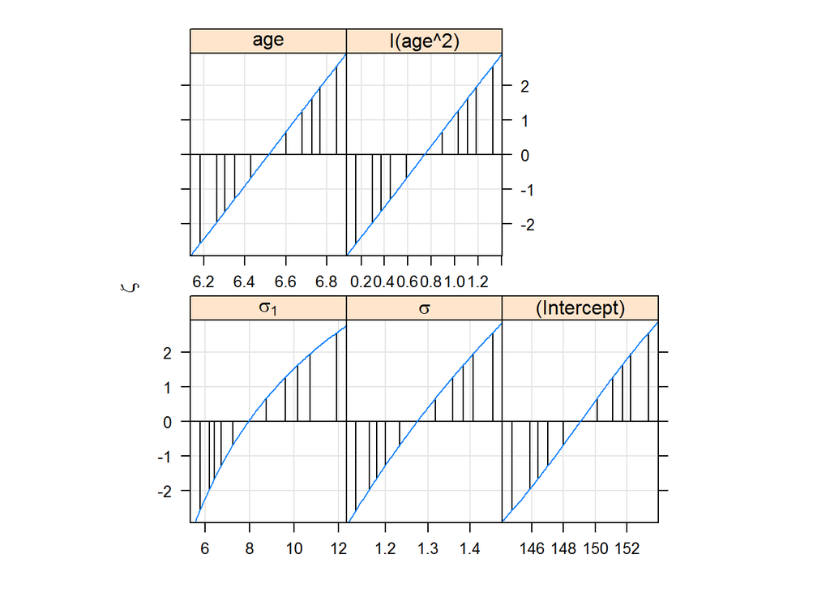

```r
fm1Pr<-profile(fm1)
xyplot(fm1Pr,aspect=1.3)
```

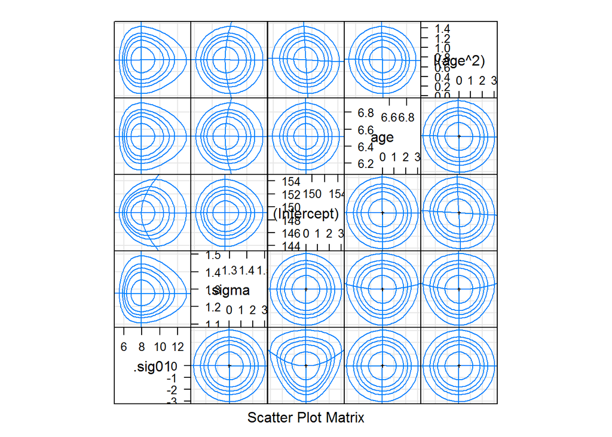

```r
splom(fm1Pr)
```

All parameters are significant, standard deviation of random intercept is skewed.  
Profile pair plot looks good.

Fit model without quadratic term and compare it with `fm1`.

(Skipped Code)

Properties of `fm2`:

```r
head(ranef(fm2)$Subject)
```

```
##    (Intercept)
## 10  -19.113952
## 26  -11.366390
## 25  -10.186153
## 9   -11.214027
## 2    -6.517476
## 6    -2.629196
```

```r
confint(fm2)
```

```
## Computing profile confidence intervals ...
```

```
##                  2.5 %     97.5 %
## .sig01        6.181494  10.711107
## .sigma        1.191337   1.444068
## (Intercept) 146.199105 152.544366
## age           6.263600   6.784237
```

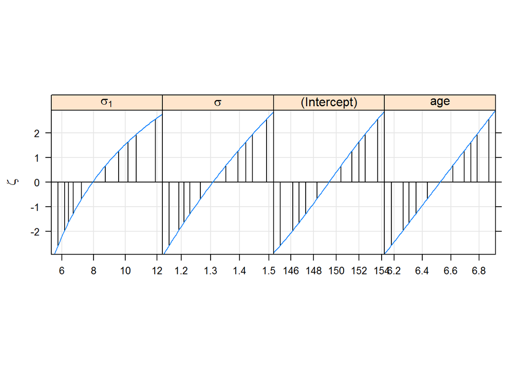

```r
fm2Pr<-profile(fm2)
xyplot(fm2Pr,aspect=1.3)
```

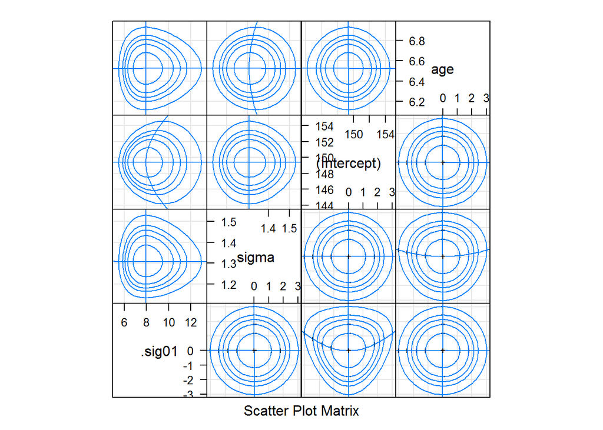

```r
splom(fm2Pr)
```

```r
anova(fm2,fm1)
```

```
## Data: Oxboys
## Models:
## fm2: height ~ age + (1 | Subject)
## fm1: height ~ age + I(age^2) + (1 | Subject)
##     Df    AIC    BIC  logLik deviance Chisq Chi Df Pr(>Chisq)
## fm2  4 948.57 962.39 -470.28   940.57
## fm1  5 940.02 957.30 -465.01   930.02 10.55      1   0.001162 **
## ---
## Signif. codes:  0 '***' 0.001 '**' 0.01 '*' 0.05 '.' 0.1 ' ' 1
```

Models appear to be not equivalent confirming importance of the quadratic term.

Check if adding random effect to the model makes enough difference.

**Note**. Comparison of models with and without random effects is not always reasonable.  
Preference for a random effects in the model may not be a result of better fit, but interpretation of the model.

Package `lme4` might have been updated and now can analyze objects of `lm()` and `lmer()`, but it appears that order in which models are given to `anova()` is important.

```r
fm3<-lm(height~age+I(age^2),data=Oxboys)
anova(fm1,fm3)
```

```
## Data: Oxboys
## Models:
## fm3: height ~ age + I(age^2)
## fm1: height ~ age + I(age^2) + (1 | Subject)
##     Df     AIC    BIC  logLik deviance  Chisq Chi Df Pr(>Chisq)
## fm3  4 1647.67 1661.5 -819.83  1639.67
## fm1  5  940.02  957.3 -465.01   930.02 709.65      1  < 2.2e-16 ***
## ---
## Signif. codes:  0 '***' 0.001 '**' 0.01 '*' 0.05 '.' 0.1 ' ' 1
```

If direct comparison by `anova()` of objects `lm()` and `lmer()` is not working then there has been a known fix.

The reason for possible problem is that `lmer()` does not allow fitting a model with only fixed effects.

But fitting fixed effects model by `lm()` and mixed effects model by `lmer()` does not always allow comparison by `anova()`.

The solution is: go to the predecessor of `lme4` S3 library `nlme` and within that library use `lme()` for mixed effects instead of `lmer()` and use `gls()` for fixed effects instead of `lm()`.

```r
suppressWarnings(library(nlme))
```

Note slightly different syntax of calling mixed effects model by `lme()`.

```r
fm3<-lme(height ~ age+I(age^2), random= ~1|Subject,data=Oxboys)
fm4<-gls(height~age+I(age^2),data=Oxboys)
anova(fm3,fm4)
```

```
##     Model df       AIC       BIC    logLik   Test  L.Ratio p-value
## fm3     1  5  940.6658  957.8779 -465.3329
## fm4     2  4 1643.1330 1656.9027 -817.5665 1 vs 2 704.4672  <.0001
```

Likelihood ratio test shows that the two models are not equivalent.  
Final choice of the model is `fm1` including both quadratic term and random intercept.

## 5.3 Visualization of the fit

Visualize the fitted model.  
See [this description](http://lattice.r-forge.r-project.org/Vignettes/src/lattice-tricks/regression-lines.pdf) for more instructions on how to visualize panel data.

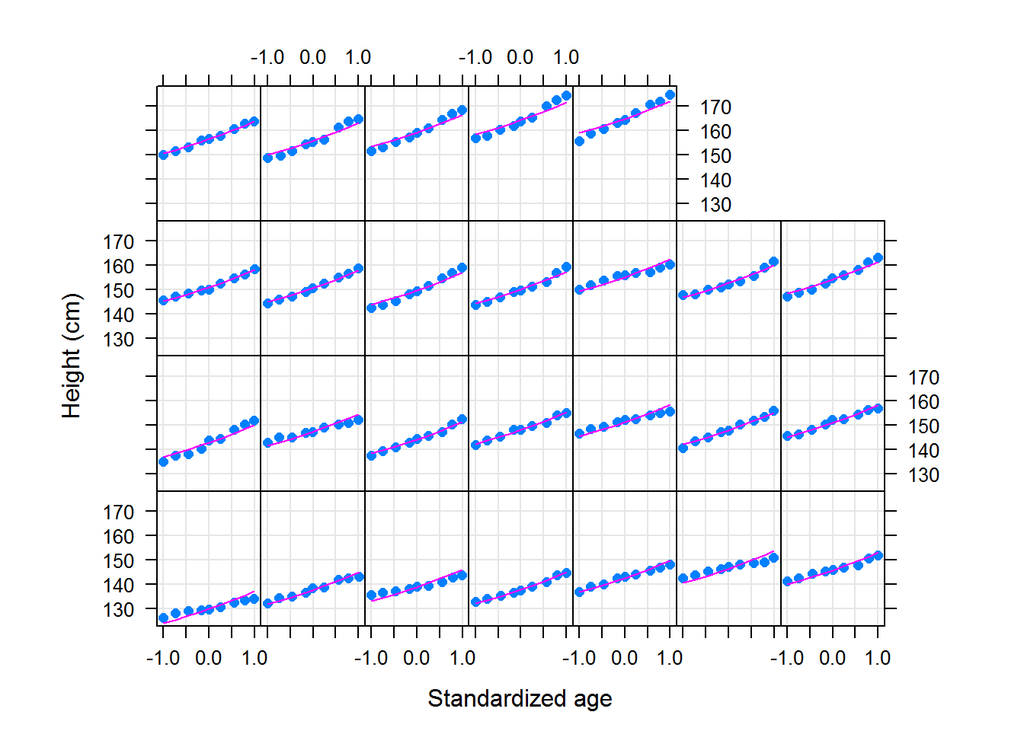

```r
xyplot(height~age|Subject,data=Oxboys,fit=fm1,strip=FALSE,
       aspect=1.3,pch=16,grid=TRUE,
       panel=function(x, y, ...,fit,subscripts) {
         panel.xyplot(x, y, ...)
         ypred <- fitted(fit)[subscripts]
         panel.lines(x, ypred, col = "magenta")
        },
       xlab = "Standardized age", ylab = "Height (cm)")
```

Note that `fitted(fit)` extracts fitted values from `fit=fm1`, but these fitted values make one column including all subjects and will not be separated into panel specific parts.  
Then subset corresponding to each panel is defined by argument `subscripts` that `lattice` passes to each panel. With `subscripts` each panel contains only fitted values corresponding to that subject.